# RSMS HW 1

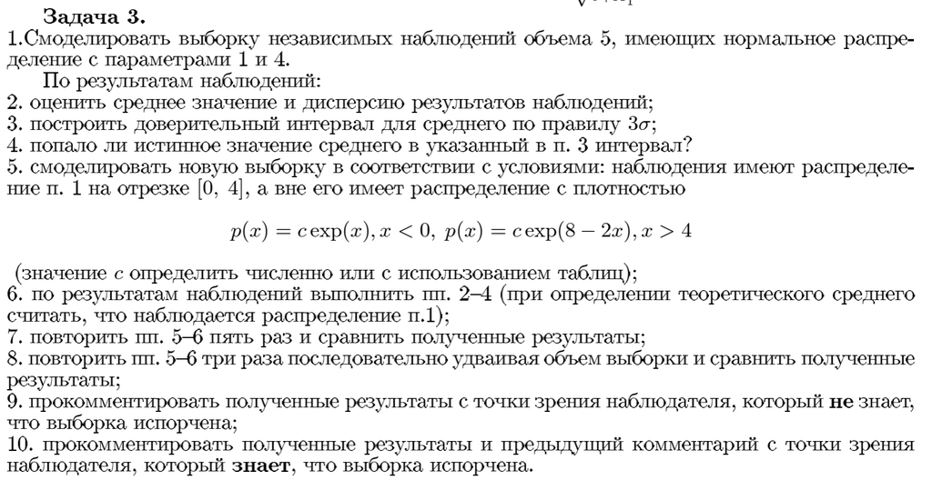

Будем использовать
$$\overline{X} =
\frac{\sum_{i=1} ^ n X_i}{n}$$
для оценки среднего и
$$s^2 = \frac{1}{n-1} \sum_{i=1} ^ n (X_i -
\overline{X})$$
для оценки дисперсии.

```r
get_est = function(sample) {
  est = c( mean(sample), var(sample))
  names(est) = c("Mean", "Variance")
  est
}
get.99ci = function(sample) {
  est = get_est(sample)
  est_sd = sqrt(est[2] / length(sample))
  mean_conf_interval_99 = c(est[1] - 3*est_sd, est[1] + 3*est_sd)
  names(mean_conf_interval_99) = c("Lower bound", "Upper bound")
  mean_conf_interval_99
}
```

Берем выборку размером 5 с параметрами $\mu=1$ и $\sigma=2$.

```r
set.seed(2023)
n=5
mean=1
sd=2
sample = rnorm(n, mean = mean, sd=sd)
est = get_est(sample)
est
```

```
##       Mean   Variance
## -0.5045703  2.0953649
```

Берем $3\sigma$ доверительный интервал

```r
get.99ci(sample)
```

```
## Lower bound Upper bound
##   -2.446646    1.437505
```

Истинное значение попало в интервал.

Теперь утяжеляем хвосты экспоненциальным распределением.

```r
sample_from_density = function(n, pdf_f, approx=1000, ...) {
  x = seq(-10, 10, length.out = approx)
  y = sapply(x, pdf_f, ...)

  random.points <- approx(
    cumsum(y)/sum(y),
    x,
    runif(n)
  )$y
  random.points
}
rlongtailed_normal = function(sd=1, mean=0, c) {
  found
}

dlongtailed_normal = function(x, c, sd=1, mean=0, normal_range=c(0, 4)) {
  if (x >= normal_range[1] & x <= normal_range[2]) {
    return(dnorm(x, mean=mean, sd=sd))
  } else {
    if (x < 0) {
      return(c * exp(x))
    } else {
      return(c * exp(8 - 2*x))
    }
  }
}

integrate = function(fn, x_range=seq(-10, 10, length.out=100), ...) {
  lambda = abs(abs(x_range[2]) - abs(x_range[1]))
  res = 0
  for (x in x_range) {
    res = res + fn(x, ...) * (lambda)
  }
  res
}

estimate_c = function(sd, mean, tol=0.01) {
  grid = seq(-100, 100, length.out=10000)

  for (c in grid) {
    total_proba = integrate(fn=dlongtailed_normal, sd=sd, mean=mean, c=c)
    #
    #for (x in x_range) {
    #  total_proba = total_proba + dlongtailed_normal(x, sd=sd, mean=mean, c=c) * (1 / length(x_range))
    #}
    if (abs(total_proba - 1) < tol) {
      return(c)
    }
  }
}


#c_right_continuous = dnorm(4, mean=mean, sd=sd)
#plot(
#  x_range,
#  lapply(x_range, dlongtailed_normal, c=c_right_continuous, mean=mean, sd=sd),
#  ylab = "f(x)",
#  xlab = "x",
#  xlim = c(-7, 7)
#)

#hist(sample_from_density(100, pdf_f = dnorm, mean = 1))
# hist(
#   sample_from_density(
#     1000,
#     dlongtailed_normal,
#     c=c_est,
#     mean=mean,
#     sd=sd
#   ),
#   xlab = "x", ylab = "empirical density",
# )
# integrate(
#   dnorm,
#   x_range=seq(0, 4, length.out=1000),
#   #c=c_est,
#   mean=mean,
#   sd=sd
# )
# integrate(
#   dlongtailed_normal,
#   x_range=seq(-10, 10, length.out=1000),
#   mean=mean,
#   sd=sd,
#   c=c_est
# )
```

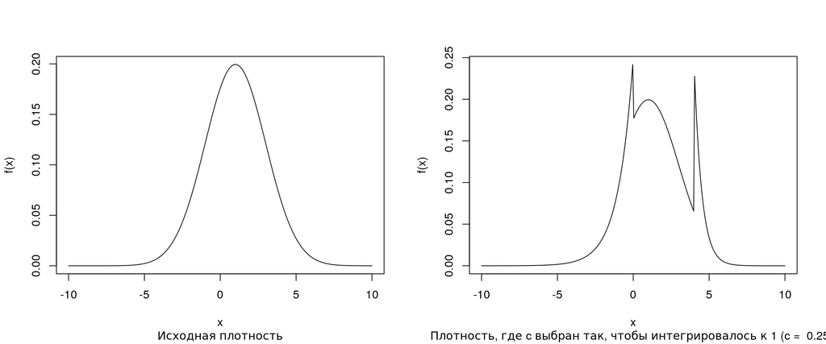

```r
par(mfrow=c(1, 2))
c_est = estimate_c(sd=sd, mean=mean)

x_range = seq(-10, 10, length.out = 300)
plot(
  x_range,
  lapply(x_range, dnorm, mean=mean, sd=sd),
  type='l',
  xlab = "x", ylab = "f(x)",
  sub="Исходная плотность"
)
plot(
  x_range,
  lapply(x_range, dlongtailed_normal, c=c_est, mean=mean, sd=sd),
  type='l',
  xlab = "x", ylab = "f(x)",
  sub=paste("Плотность, где c выбран так, чтобы интегрировалось к 1 (c = ", round(c_est, 2), ")")
)
```

Настоящее среднее такого распределения.

```r
sample = sample_from_density(
  100000,
  dlongtailed_normal,
  c=c_est,
  mean=mean,
  sd=sd
)
c(mean(sample), var(sample), median(sample))
```

```
## [1] 1.374269 3.667168 1.281418
```

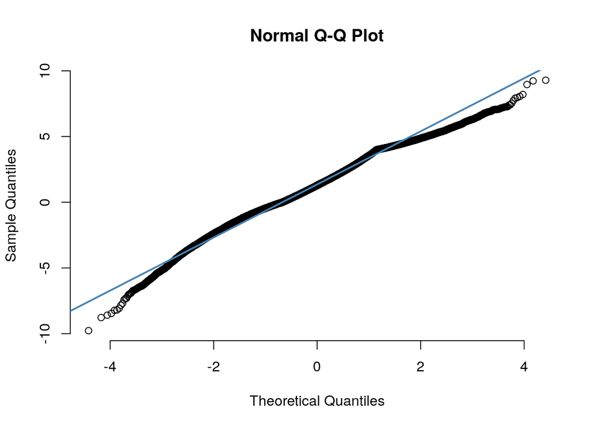

```r
qqnorm(sample, pch = 1, frame = FALSE)
qqline(sample, col = "steelblue", lwd = 2)
```

```r
run_samples = function(n_samples, density, sample_size=5, ...) {
  ci_matrix = matrix(, ncol=2, nrow=0)
  est_matrix = matrix(, ncol=2, nrow=0)
  for (i in 1:n_samples) {
    longtailed_sample = sample_from_density(
      n=sample_size,
      pdf_f=density,
      approx=1000,
      ...
    )
    ci_matrix = rbind(ci_matrix, get.99ci(longtailed_sample))
    est_matrix = rbind(est_matrix, get_est(longtailed_sample))
  }
  list("ci_matrix" = ci_matrix, "est_matrix" = est_matrix)
}
```

Повторяем пп.2-4 для нового распределения

```r
set.seed(2023)
run_samples(
  n_samples=1,
  sample_size=5,
  density=dlongtailed_normal,
  c=c_est, mean=mean, sd=sd
)
```

```
## $ci_matrix
##      Lower bound Upper bound
## [1,]   -1.781963    1.687704
##
## $est_matrix
##             Mean Variance
## [1,] -0.04712957 1.672026
```

Повторяем операцию
$$n=5$$
раз.

```r
set.seed(2023)
run_samples(
  n_samples=5,
  sample_size=5,
  density=dlongtailed_normal,
  c=c_est, mean=mean, sd=sd
)
```

```
## $ci_matrix
##      Lower bound Upper bound
## [1,] -1.78196277    1.687704
## [2,] -0.70942928    2.029368
## [3,] -1.44241486    6.659331
## [4,] -1.14108985    3.858989
## [5,]  0.03315257    4.038461
##
## $est_matrix
##             Mean Variance
## [1,] -0.04712957 1.672026
## [2,]  0.65996925 1.041807
## [3,]  2.60845831 9.116430
## [4,]  1.35894936 3.472331
## [5,]  2.03580664 2.228124
```

```r
# set.seed(2023)
# for (n_samples in c(5, 10, 20, 30, 40, 50, 100)) {
#   #print(run_samples(n_samples))
#   print(paste("Результаты для n=", n_samples))
#   run_samples(
#     n_samples=100,
#     sample_size=n_samples,
#     density=dlongtailed_normal,
#     c=c_est, mean=mean, sd=sd
#   )$ci_matrix
#
# }
```

При переходе от $n=5$ к $n=10$, а также от $n=20$ к $n=30$ интервалы оказались невложенными, а длинна увеличилась

```r
set.seed(2023)
for (n_samples in c(5, 10, 20, 30, 40, 50, 100)) {
  #print(run_samples(n_samples))
  print(paste("Результаты для n=", n_samples))
  res = (run_samples(
    n_samples=1,
    sample_size=n_samples,
    density=dnorm,
    mean=mean, sd=sd
  ))
  res$ci_length = res$ci_matrix[2] - res$ci_matrix[1]
  print(res)
}
```

```
## [1] "Результаты для n= 5"
## $ci_matrix
##      Lower bound Upper bound
## [1,]   -2.407994    1.483285
##
## $est_matrix
##            Mean Variance
## [1,] -0.4623544 2.103063
##
## $ci_length
## [1] 3.891279
##
## [1] "Результаты для n= 10"
## $ci_matrix
##      Lower bound Upper bound
## [1,]   -1.217378    3.825434
##
## $est_matrix
##          Mean Variance
## [1,] 1.304028 7.063876
##
## $ci_length
## [1] 5.042812
##
## [1] "Результаты для n= 20"
## $ci_matrix
##      Lower bound Upper bound
## [1,]   0.1136328    2.188373
##
## $est_matrix
##          Mean Variance
## [1,] 1.151003 2.391414
##
## $ci_length
## [1] 2.07474
##
## [1] "Результаты для n= 30"
## $ci_matrix
##      Lower bound Upper bound
## [1,]   0.5478992     2.66133
```

[output cut: 28 more lines]

```
##
## $ci_length
## [1] 1.658724
##
## [1] "Результаты для n= 100"
## $ci_matrix
##      Lower bound Upper bound
## [1,]   0.3652071    1.575858
##
## $est_matrix
##           Mean Variance
## [1,] 0.9705324 4.071319
##
## $ci_length
## [1] 1.210651
```

В математическом ожидании интервалы сужаются, то есть $E[ 6\hat{\sigma_{\overline{X}}} ] (\text{длина 3-сигма интервала}) \xrightarrow[n \xrightarrow{} \infty]{} 0$. Вот что будет, если брать усредненный доверительный интервал для тех же самых размеров выборки:

1. Для каждого $n=5,10,20,30$
2. Берем 100 выборок размера $n$
3. Для каждой выборки строим доверительный 3-сигма интервал
4. Усредняем полученные 100 левых и правых границ интервалов соответственно.

Таким образом получается оценка математического ожидания левой ($\text{lower.bound}$) и правой границ ($\text{upper.bound}$) интервала, и, как можно видеть, интервалы получаются вложенными, а длина интервалов ($\text{ci.length}$) действительно уменьшается.

```r
set.seed(2023)
for (n_samples in c(5, 10, 20, 30, 40, 50, 100)) {
  #print(run_samples(n_samples))
  print(paste("Результаты для n=", n_samples))
  ci_matrix = run_samples(
    n_samples=100,
    sample_size=n_samples,
    density=dlongtailed_normal,
    c=c_est, mean=mean, sd=sd
  )$ci_matrix
  lower.bound = mean(ci_matrix[, 1])
  upper.bound = mean(ci_matrix[, 2])
  ci_length = upper.bound - lower.bound

  res = c(lower.bound, upper.bound, ci_length)
  names(res) = c("lower.bound", "upper.bound", "ci.length")
  print(res)
}
```

```
## [1] "Результаты для n= 5"
## lower.bound upper.bound   ci.length
##  -0.9947295   3.7271856   4.7219151
## [1] "Результаты для n= 10"
## lower.bound upper.bound   ci.length
##  -0.4779919   3.0034619   3.4814539
## [1] "Результаты для n= 20"
## lower.bound upper.bound   ci.length
##  0.08144518  2.59153072  2.51008554
## [1] "Результаты для n= 30"
## lower.bound upper.bound   ci.length
##   0.3155789   2.3376089   2.0220300
## [1] "Результаты для n= 40"
## lower.bound upper.bound   ci.length
##   0.4636951   2.2873637   1.8236686
## [1] "Результаты для n= 50"
## lower.bound upper.bound   ci.length
##    0.532547    2.139993    1.607446
## [1] "Результаты для n= 100"
## lower.bound upper.bound   ci.length
##   0.8047788   1.9452441   1.1404653
```

Сравнение распределений левой границы доверительного интервала для испорченного распределения при разных $n$.

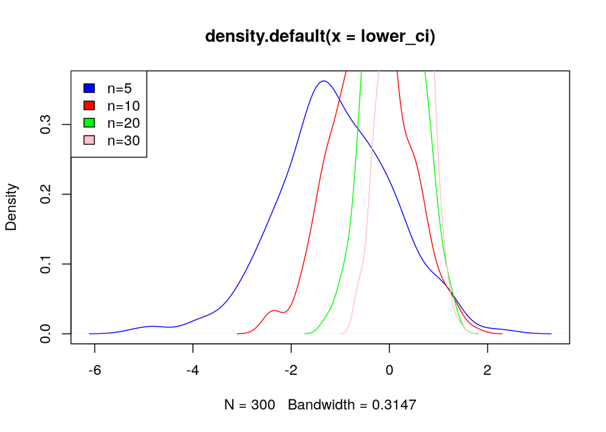

```r
set.seed(2023)
f_range = seq(-5, 5, length.out=50)

colors = c("blue", "red", "green", "pink", "orange")
col_i = 1

for (sample_size in c(5, 10, 20, 30)) {
  #print(run_samples(n_samples))
  lower_ci = run_samples(
    n_samples=300,
    sample_size=sample_size,
    density=dlongtailed_normal,
    c=c_est, mean=mean, sd=sd
  )$ci_matrix[, 1]

  if (col_i == 1) {
    plot(density(lower_ci), col=colors[col_i])
  } else {
    lines(density(lower_ci), col=colors[col_i])
  }
  col_i = col_i + 1

}

legend(x="topleft", legend=c("n=5", "n=10", "n=20", "n=30"), fill=colors)
```

Сравнение распределений длин доверительного интервала для испорченного распределения при разных $n$.

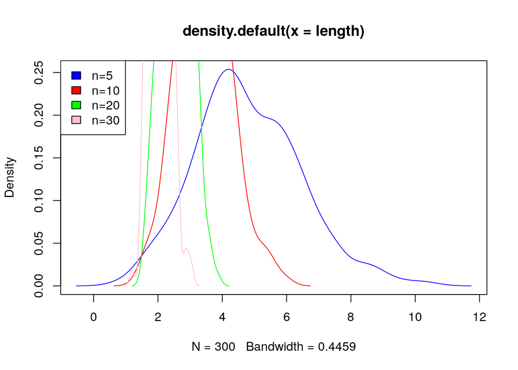

```r
set.seed(2023)
f_range = seq(-5, 5, length.out=50)

colors = c("blue", "red", "green", "pink", "orange")
col_i = 1

for (sample_size in c(5, 10, 20, 30)) {
  #print(run_samples(n_samples))
  ci = run_samples(
    n_samples=300,
    sample_size=sample_size,
    density=dlongtailed_normal,
    c=c_est, mean=mean, sd=sd
  )
  length = ci$ci_matrix[, 2] - ci$ci_matrix[, 1]

  if (col_i == 1) {
    plot(density(length), col=colors[col_i])
  } else {
    lines(density(length), col=colors[col_i])
  }
  col_i = col_i + 1

}

legend(x="topleft", legend=c("n=5", "n=10", "n=20", "n=30"), fill=colors)
```

Колебания длины интервала при маленьких выборках обусловлены высокой дисперсией оценки (которая стремится к нулю при $n \xrightarrow{} \infty$).

```r
# sample_size = 100
# c = 0
# samples = run_samples(
#     n_samples=1000,
#     sample_size=sample_size,
#     density=dnorm,
#     mean=mean, sd=sd
# )$ci_matrix
#
#
# for (i in 1:1000) {
#   if ((samples[i,][2] > 1) && (samples[i][1] < 1)) {
#     c = c + 1
#   }
# }
# c
```

Поподробнее разберемся, когда $\mu=1$ будте попадать в доверительный интервал из испорченного распределения.

Повторим построение доверительного интервала из испорченного распределения для размеров выборки $n=2,..,100$ и выведем все случаи, когда $\mu=1$ не попало в доверительный интервал.

```r
set.seed(2023)
times = c()

for (sample_size in seq(2, 100)) {
  #print(run_samples(n_samples))
  ci = run_samples(
    n_samples=1,
    sample_size=sample_size,
    density=dlongtailed_normal,
    c=c_est, mean=mean, sd=sd
  )$ci_matrix
  if ((ci[1, 2] > 1) && (ci[1, 1] < 1)) {
  } else {
    times = append(times, sample_size)
  }
}
times
```

```
##  [1]  14  36  68  71  74  82  86  88  89  98 100
```

Оценим мат ожидание попадания $\mu=1$ в интервал при разных $n$. С увелечением размера выборки для испорченного распределения, растет вероятность непопадания $\mu=1$ в доверительный интервал

```r
set.seed(2023)
probas = c()

for (sample_size in seq(2, 100)) {
  #print(run_samples(n_samples))
  ci = run_samples(
    n_samples=100,
    sample_size=sample_size,
    density=dlongtailed_normal,
    c=c_est, mean=mean, sd=sd
  )$ci_matrix
  times_for_sample_size = 0
  for (i in seq(1, 100)) {
    if ((ci[i, 2] > 1) && (ci[i, 1] < 1)) {
    } else {
      times_for_sample_size = times_for_sample_size + 1
    }
  }
  probas = append(probas, times_for_sample_size / 100)
}

probas_normal = c()

for (sample_size in seq(2, 100)) {
  #print(run_samples(n_samples))
  ci = run_samples(
    n_samples=100,
    sample_size=sample_size,
    density=dnorm,
    mean=mean, sd=sd
  )$ci_matrix
  times_for_sample_size = 0
  for (i in seq(1, 100)) {
    if ((ci[i, 2] > 1) && (ci[i, 1] < 1)) {
    } else {
      times_for_sample_size = times_for_sample_size + 1
    }
  }
  probas_normal = append(probas_normal, times_for_sample_size / 100)
}
```

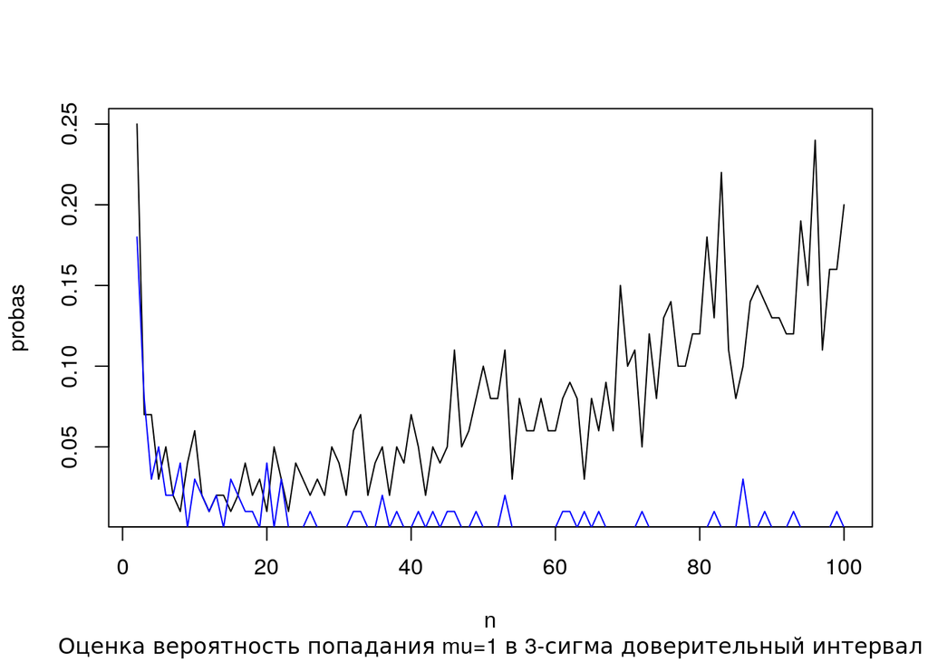

```r
plot(seq(2,100), probas, type='l', sub = "Оценка вероятность попадания mu=1 в 3-сигма доверительный интервал", xlab="n")
lines(seq(2,100), probas_normal, type='l', col="blue")

legend(1, 95, legend=c("Испореченное распределение", "Нормальное распределение"),
       col=c("red", "blue"), lty=1:2, cex=0.8)
```

```r
normal_cis_upper = c()
normal_cis_lower = c()
abnormal_cis_upper = c()
abnormal_cis_lower = c()
for (sample_size in seq(2, 100)) {
  #print(run_samples(n_samples))
  ci = run_samples(
    n_samples=100,
    sample_size=sample_size,
    density=dnorm,
    mean=mean, sd=sd
  )$ci_matrix
  abnormal_ci = run_samples(
    n_samples=100,
    sample_size=sample_size,
    density=dlongtailed_normal,
    c=c_est, mean=mean, sd=sd
  )$ci_matrix
  normal_cis_upper = append(normal_cis_upper, mean(ci[,2]))
  normal_cis_lower = append(normal_cis_lower, mean(ci[,1]))
  abnormal_cis_upper = append(abnormal_cis_upper, mean(abnormal_ci[,2]))
  abnormal_cis_lower = append(abnormal_cis_lower, mean(abnormal_ci[,1]))
}
```

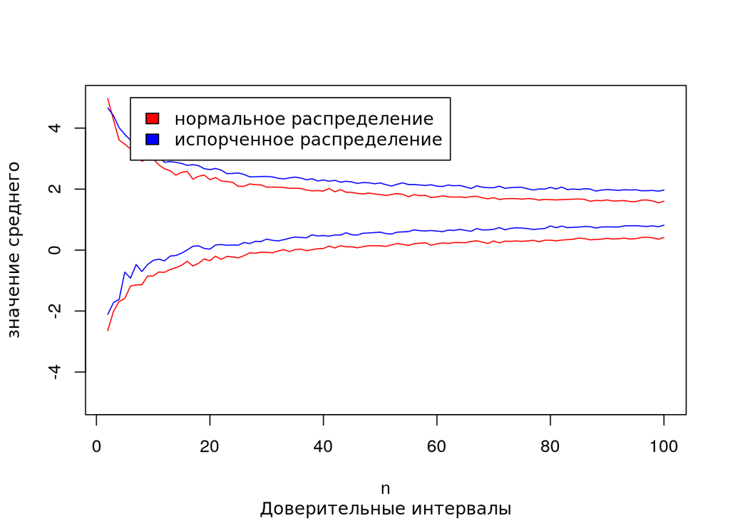

```r
plot(seq(2, 100), normal_cis_lower, col="red", type='l', ylim=c(-5,5), xlab="n", sub="Доверительные интервалы", ylab="значение среднего")
lines(seq(2, 100), normal_cis_upper, col="red")
lines(seq(2, 100), abnormal_cis_upper, col="blue")
lines(seq(2, 100), abnormal_cis_lower, col="blue")
legend(6, 5, legend=c("нормальное распределение", "испорченное распределение"),
       fill=c("red", "blue"))
```

При каком $n$ можно обнаружить, что выборка испорчена?

Для разных значений $n$, оценим p-value для Shapiro-Wilk теста на нормальность.

```r
# shapiro.test(rnorm(100, mean=0, sd=100))
```

```r
set.seed(2023)
normal_pvalues = c()
abnormal_pvalues = c()
for (sample_size in seq(5, 100)) {
  normal_pvalues_for_sample_size = c()
  abnormal_pvalues_for_sample_size = c()
  for (i in seq(1:100)) {
    long_sample = sample_from_density(
      sample_size,
      dlongtailed_normal,
      c=c_est,
      mean=mean,
      sd=sd
    )
    sample = sample_from_density(
      sample_size,
      dnorm,
      mean=mean,
      sd=sd
    )
    normal_pvalues_for_sample_size = append(normal_pvalues_for_sample_size, shapiro.test(sample)$p.value)
    abnormal_pvalues_for_sample_size = append(abnormal_pvalues_for_sample_size, shapiro.test(long_sample)$p.value)
  }
  normal_pvalues = append(normal_pvalues, mean(normal_pvalues_for_sample_size))
  abnormal_pvalues = append(abnormal_pvalues, mean(abnormal_pvalues_for_sample_size))
}
```

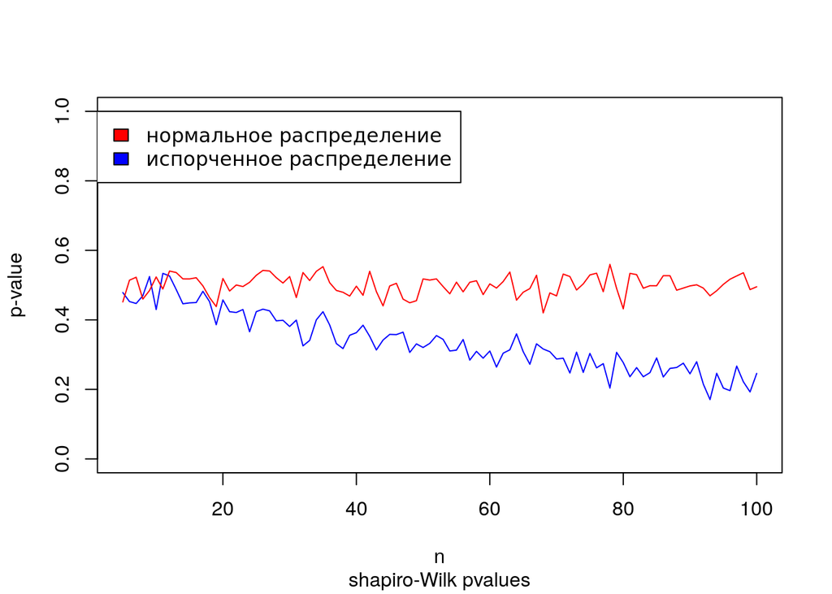

```r
plot(seq(5, 100), abnormal_pvalues, col="blue", type='l', ylim=c(0,1), xlab="n", sub="shapiro-Wilk pvalues", ylab="p-value")
lines(seq(5, 100), normal_pvalues, col="red")
# lines(seq(2, 100), abnormal_cis_upper, col="blue")
# lines(seq(2, 100), abnormal_cis_lower, col="blue")
legend(1, 1, legend=c("нормальное распределение", "испорченное распределение"),
       fill=c("red", "blue"))
```

```r
# set.seed(2023)
# sample = rnorm(100)
# print(get.99ci(sample[seq(1,15)]))
# print(get.99ci(sample[seq(1,20)]))
# get.99ci(sample[seq(1,30)])
# get.99ci(sample[seq(1,100)])
```

```r
# С ростом количества наблюдений интервал в среднем сужается
# data = data.frame(matrix(ncol=3, nrow=0))
# colnames(data) = c("sample_size", "ci", "mean")
# data = data.frame(sample_size=c(0), ci=c(0), mean=c(0))
# # rbind(data, c(1,1,1))
# for (sample_size in c(5, 10, 20, 30, 50, 100)) {
#   ci_matrix = run_samples(
#     n_samples=300,
#     sample_size=sample_size,
#     density=dnorm,
#     mean=mean, sd=sd
#   )$ci_matrix
#   interval_lengths = ci_matrix[, 2] - ci_matrix[, 1]
#   interval_means = (ci_matrix[, 2] + ci_matrix[, 1]) / 2
#   # da
# }
```

Сравнение эмпирических распределений большой выборки

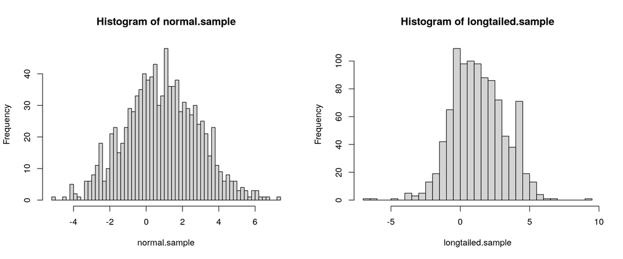

```r
par(mfrow = c(1, 2))

set.seed(2023)
longtailed.sample = sample_from_density(
  1000,
  dlongtailed_normal,
  sd=sd, mean=mean, c=c_est
)

normal.sample = sample_from_density(
    1000,
    dnorm,
    mean=mean, sd=sd
  )
hist(normal.sample, breaks = 50)
hist(longtailed.sample, breaks = 50)
```

```r
#Сравнение эмпирических распределений статистик
par(mfrow = c(2, 2))

set.seed(2023)
longtailed.samples = run_samples(
  n_samples=1000,
  sample_size=30,
  density=dlongtailed_normal,
  c=c_est, mean=mean, sd=sd
)
longtailed.means = longtailed.samples$est_matrix[, 1]
longtailed.variances = longtailed.samples$est_matrix[, 2]

samples = run_samples(
  n_samples=1000,
  sample_size=30,
  density=dnorm,
  mean=mean, sd=sd
)
means = samples$est_matrix[, 1]
variances = samples$est_matrix[, 2]
#hist(longtailed.means)
#hist(longtailed.variances)
#hist(means)
#hist(variances)
```

Наблюдатель, который не знает, что выборка испорчена может получить неэффективные оценки свойств распределения.

Наблюдатель который знает, что выборка испорчена, может использовать робастные оценки.

```r
library(VGAM)
```

```r
par(mfrow=c(1,2))
#hist(rlaplace(1000))
#hist(rnorm(1000))
```

```r
# library(lawstat)
# symmetry.test(
#   sample_from_density(
#     1000,
#     pdf_f=dlongtailed_normal,
#     sd=sd,mean=mean,c=c_est
#   )
# )
```